# Лекция 13. Отбор в выборку: модели Хекмана

Блок 3. Естественные эксперименты и отбор по ненаблюдаемым

Карен Аванесян

Каузальный анализ в R на данных RLMS-HSE

# Зачем

## Зарплату видно не у всех

- Хотим знать отдачу от образования **для женщин вообще**. Но зарплата наблюдается только у тех, кто работает: у домохозяек, в декрете, у безработных её нет
- Если решение работать связано с тем, сколько женщина **могла бы** заработать, то работающие — не случайная выборка. МНК по работающим отвечает на другой вопрос
- Это не «отбор в воздействие» (блоки 1–2), а **отбор в выборку**: исход есть не у всех. Так же устроены вопросы о зарплате мигрантов, оценках сдавших ЕГЭ, доходе выживших фирм

Хекман (1979, Нобелевская премия 2000) предложил моделировать сам отбор и поправлять на него уравнение исхода. Цена — сильные допущения о совместном распределении ошибок и **исключающее ограничение**.

## Пример занятия

3 191 женщин 25–49 лет, RLMS 2018

79% работают и сообщают зарплату

8% имеют ребёнка младше 3 лет

753 замужних женщин в классике Mroz (1987)

вопрос

### Отдача от образования для женщин

Год обучения → % к зарплате. МНК по работающим против модели отбора.

план

### Симуляция → классика → RLMS

Сначала там, где истина известна; затем учебник Mroz; затем наши данные — где модель ломается.

## План занятия

1. Модель отбора: два уравнения, коррелированные ошибки
2. Обратное отношение Миллса и двухшаговая оценка
3. Исключающее ограничение: зачем и чем опасно его отсутствие
4. Симуляция, Mroz (1987), RLMS
5. Как читать вывод `sampleSelection` и писать результат
6. Модель с эндогенным бинарным воздействием — мост к лекции 14

# Идея

## Модель отбора

$$s_i^* = Z_i\gamma + u_i, \qquad s_i = \mathbb{1}[s_i^* > 0] \quad \text{(работает ли)}$$
$$y_i = X_i\beta + \varepsilon_i, \quad \text{наблюдается только при } s_i = 1 \quad \text{(зарплата)}$$

- $(u_i, \varepsilon_i)$ — двумерное нормальное, корреляция $\rho$, дисперсия $\varepsilon$ равна $\sigma^2$
- $\rho > 0$: работают те, у кого ненаблюдаемая «зарплатная сила» выше — МНК по работающим **завышает** средний уровень и обычно **занижает** отдачу от образования
- $\rho = 0$: отбор случаен при данных $Z$ — МНК по работающим не смещён

## Откуда смещение

$$E[y_i \mid X_i, s_i = 1] = X_i\beta + \underbrace{\rho\,\sigma}_{\beta_\lambda}\;\underbrace{\lambda(Z_i\gamma)}_{\text{обратное отношение Миллса}}$$

- $\lambda(\cdot) = \phi(\cdot)/\Phi(\cdot)$ — велико у тех, кого почти не взяли в выборку: только «необычные» из них работают
- МНК по работающим — это **пропущенная переменная** $\lambda$ (лекция 4). Если $\lambda$ коррелирует с $X$, коэффициенты смещены
- Исправление: оценить $\gamma$ пробитом, посчитать $\hat\lambda_i$, добавить его в регрессию зарплаты

## Два способа оценить

heckit · двухшаговый

### Пробит → $\hat\lambda$ → МНК

Прозрачно, легко объяснить. Ошибки второго шага надо корректировать (пакет делает). $\hat\rho$ может выйти за $[-1, 1]$ — это сигнал проблемы.

selection · ML

### Совместное правдоподобие

Эффективнее, даёт $\hat\rho$ с ошибкой. Чувствительнее к нормальности и может упираться в $\rho \to \pm 1$.

Расхождение двухшаговой и ML-оценок — не мелочь, а диагностика: модель плохо идентифицирована или неверно специфицирована.

## Исключающее ограничение

**Нужна переменная** в $Z$, которой нет в $X$: влияет на решение работать, но не на ставку зарплаты

**Без неё** $\lambda$ почти линейна по $X$ — поправка держится только на форме нормального распределения

**Классика:** маленькие дети, доход мужа, нетрудовые доходы

**Проверка аргументом**, а не тестом: как при IV (лекция 12), исключение не тестируется

- Дети в RLMS — естественный кандидат. Но лекция 8 показала **штраф за материнство** в заработках: дети, возможно, влияют на ставку напрямую. Тогда исключение нарушено

# Код

## Симуляция: истина известна

Отбор зависит от $x$, от исключающей переменной $z$ и от ошибки, коррелированной с ошибкой зарплаты ($\rho = 0.7$). 200 повторов по 2000 наблюдений.

- Результат
- Код симуляции

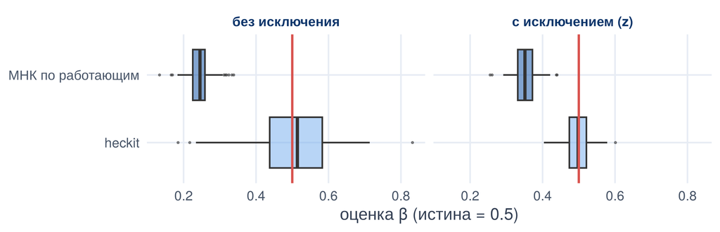

```r
sim_heck <- function(seed, n = 2000, rho = 0.7, excl = TRUE) {
  set.seed(seed)
  x <- rnorm(n); z <- rnorm(n)
  e <- MASS::mvrnorm(n, c(0, 0), matrix(c(1, rho, rho, 1), 2))   # коррелированные ошибки
  s <- (0.3 + 0.8 * x + (if (excl) 1.0 * z else 0) + e[, 1]) > 0  # отбор: z только здесь
  d <- data.frame(s, y = ifelse(s, 1 + 0.5 * x + e[, 2], NA), x, z)
  c(ols = unname(coef(lm(y ~ x, d))["x"]), heck = hx(if (excl) s ~ x + z else s ~ x, d))
}
```

## Что показала симуляция

| дизайн | МНК: среднее | heckit: среднее | heckit: разброс (sd) |
| --- | --- | --- | --- |
| без исключения | 0.244 | 0.504 | 0.119 |
| с исключением (z) | 0.352 | 0.499 | 0.035 |

- При $\rho = 0.7$ МНК по работающим систематически занижает $\beta$: отбор шёл по $x$ **и** по ненаблюдаемым
- С исключающей переменной heckit попадает в 0.5. Без неё — в среднем тоже, но разброс в разы больше: поправка держится на изгибе нормального распределения
- На реальных данных «в среднем верно при огромном разбросе» означает «одна выборка может дать что угодно»

## Классика: Mroz (1987)

753 замужние женщины, США 1975; работает 57%. Исключения — дети до 6, дети 6–18, доход семьи без жены:

```r
data(Mroz87, package = "sampleSelection")
m_mroz <- selection(lfp ~ age + I(age^2) + nwifeinc + kids5 + kids618 + educ + exper + I(exper^2) + city,
                    log(wage) ~ educ + exper + I(exper^2) + city, data = Mroz87, method = "2step")
ols_mroz <- lm(log(wage) ~ educ + exper + I(exper^2) + city, data = Mroz87, subset = lfp == 1)
```

0.106 МНК по работающим: отдача от года обучения

0.107 heckit: та же отдача с поправкой

0.02 $\hat\rho$: корреляция ошибок

Отбор есть (работает лишь 57%), но он почти не связан с ненаблюдаемой «зарплатной силой»: $\hat\rho \approx 0$, оценки совпадают. Поправка Хекмана не обязана что-то менять.

## Как читать вывод `selection()`

- Вывод R
- С пояснениями

```
2-step Heckman / heckit estimation
753 observations (325 censored and 428 observed)
Probit selection equation:
             Estimate Std. Error t value        Pr(>|t|)
nwifeinc    -0.012192   0.004971   -2.45          0.0144 *
kids5       -0.854484   0.121243   -7.05 0.0000000000042 ***
kids618      0.030784   0.044690    0.69          0.4911
Outcome equation:
             Estimate Std. Error t value       Pr(>|t|)
educ         0.106502   0.015845    6.72 0.000000000036 ***
   Error terms:
              Estimate Std. Error t value Pr(>|t|)
invMillsRatio   0.0154     0.1351    0.11     0.91
sigma           0.6629         NA      NA       NA
rho             0.0233         NA      NA       NA
```

1 · шапка

**2-step / ML**, сколько наблюдений **censored** (зарплаты нет) и **observed**. Проверьте, что «censored» — это действительно неработающие, а не пропуски

2 · probit selection

Уравнение отбора. Смотрите на **исключающие переменные**: они должны быть сильными (|t| ≫ 2), как первая стадия в IV

3 · outcome

Уравнение зарплаты **с поправкой**. Коэффициенты читаются как в обычной регрессии: % к зарплате на единицу $X$ для всей популяции

4 · invMillsRatio

Коэффициент при $\lambda$ = $\rho\sigma$. Его t-тест — тест «есть ли отбор по ненаблюдаемым» (при верной модели)

5 · rho

Корреляция ошибок. В двухшаговой оценке **не должна** выходить за $[-1, 1]$; в ML — упираться в ±1

6 · сигналы беды

$|\hat\rho| > 1$; ML и 2-step сильно расходятся; знак отбора противоречит теории; результат меняется при смене исключений

## Шаблон вывода для статьи

шаблон

«С поправкой на отбор в занятость (модель Хекмана, исключающие ограничения: число детей до 6 лет, 6–18 лет и доход семьи без жены) отдача от года обучения составляет **10.7%** (s.e. …), что практически совпадает с МНК по работающим (10.6%). Корреляция ненаблюдаемых факторов занятости и зарплаты близка к нулю ($\hat\rho$ = 0.02): данных о значимом отборе по ненаблюдаемым нет — **при условии**, что дети и доход мужа не влияют на ставку зарплаты напрямую.»

- Всегда называйте исключающие переменные и допущение, на котором держится поправка
- Сообщайте МНК рядом с Хекманом: читатель должен видеть, что именно сделала поправка

## RLMS: три оценки одного эффекта

```r
m_ols  <- lm(f_out, data = w)
m_2st  <- heckit(f_sel, f_out, data = w)
m_ml   <- selection(f_sel, f_out, data = w)
m_noex <- selection(works ~ years_educ + age + age2 + urban + married, f_out, data = w)
```

| модель | отдача от года обучения | rho |
| --- | --- | --- |
| МНК по работающим | 0.056 | NA |
| heckit, исключения: дети | -0.037 | -1.364 |
| ML, исключения: дети | 0.021 | -0.843 |
| ML, без исключений | 0.059 | 0.071 |

## Что пошло не так

диагностика

### Модель сама подаёт сигналы

теория

### Знак отбора странный

$\rho < 0$ значит: работают те, кто при тех же $X$ заработал бы **меньше**. Для молодых матерей в России это трудно обосновать

- Главный подозреваемый — исключающее ограничение: дети, скорее всего, влияют на ставку зарплаты (штраф за материнство, лекция 8). Тогда поправка ловит не отбор, а пропущенный эффект детей
- Вывод: на этих данных модель Хекмана **не** даёт надёжной поправки. Честный отчёт — МНК, явное описание отбора и проверки ниже

## Проверка без модели: «идентификация на бесконечности»

Если вероятность работать близка к 1, отбора почти нет. МНК-оценка среди женщин с высокой прогнозной вероятностью занятости:

- Результат
- Код

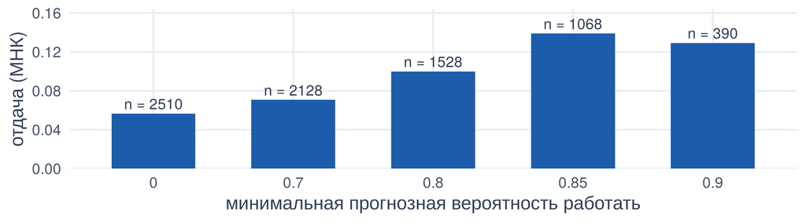

```r
pr <- glm(f_sel, family = binomial("probit"), data = w)
w$p_hat <- predict(pr, type = "response")
tibble(порог = c(0, .7, .8, .85, .9)) |>
  mutate(оценка = map_dbl(порог, \(c0) coef(lm(f_out, filter(w, p_hat >= c0)))["years_educ"]),
         n = map_int(порог, \(c0) sum(w$works & w$p_hat >= c0))) |>
  ggplot(aes(factor(порог), оценка)) + geom_col(fill = pal["indigo"], width = .6) +
  geom_text(aes(label = paste0("n = ", n)), vjust = -0.4, size = 3.6, colour = pal["charcoal"]) +
  labs(x = "минимальная прогнозная вероятность работать", y = "отдача (МНК)")
```

Среди «почти наверняка работающих» отдача **выше**, а не ниже — противоположно модели с $\rho < 0$.

## Эндогенное воздействие: та же модель, другой вопрос

Если вместо «наблюдается ли $y$» стоит «получил ли воздействие $D$», те же два уравнения дают **модель эффекта воздействия** (treatment effects model):

$$D_i = \mathbb{1}[Z_i\gamma + u_i > 0], \qquad y_i = X_i\beta + \tau D_i + \varepsilon_i, \quad \text{corr}(u, \varepsilon) = \rho$$

- Результат
- Код

| метод | оценка τ | rho |
| --- | --- | --- |
| МНК | 1.740 | NA |
| treatReg (Хекман) | 0.927 | 0.63 |

МНК завышает эффект почти вдвое: в воздействие отбираются люди с высокими ненаблюдаемыми. Модель Хекмана возвращает $\tau \approx 1$ и оценивает $\rho$.

```r
set.seed(3); n <- 3000
x <- rnorm(n); z <- rnorm(n)
e <- MASS::mvrnorm(n, c(0, 0), matrix(c(1, .6, .6, 1), 2))
d <- as.integer(0.2 + 0.5 * x + 0.8 * z + e[, 1] > 0)   # отбор в воздействие по ненаблюдаемым
y <- 1 + 0.5 * x + 1.0 * d + e[, 2]                     # истинный эффект τ = 1
tr <- treatReg(d ~ x + z, y ~ x + d, data = data.frame(y, x, z, d))
tibble(метод = c("МНК", "treatReg (Хекман)"),
       `оценка τ` = c(coef(lm(y ~ x + d))["d"], coef(tr)["d"]), rho = c(NA, coef(tr)["rho"])) |>
  mutate(across(-метод, \(v) round(v, 3)))
```

## Мост к лекции 14

- В этой модели $\rho$ — ровно то, что мы не наблюдаем: насколько отбор в воздействие связан с ненаблюдаемыми факторами исхода
- Хекман **оценивает** $\rho$, опираясь на исключающее ограничение и нормальность. Если исключения нет или оно сомнительно — оценка ненадёжна
- Altonji, Elder, Taber (2005) предлагают другой путь: **не оценивать** $\rho$, а задавать его и спрашивать, при каком $\rho$ эффект исчезает. Это лекция 14

Модель Хекмана — не «кнопка поправки на отбор», а структурная модель. Она полезна, когда есть правдоподобное исключение, и опасна, когда его нет.

# Как ошибаются

## Шесть ошибок с моделями отбора

ошибка 1

### Хекман без исключающего ограничения

**Как правильно:** найти переменную, влияющую только на отбор, или сообщить, что поправка держится на нормальности, и показать чувствительность

ошибка 2

### Исключение «по традиции»

**Как правильно:** аргументировать, почему дети/доход мужа не влияют на ставку; проверить против лекции 8 (штраф за материнство)

ошибка 3

### Игнорировать $|\hat\rho| > 1$

**Как правильно:** считать это сигналом неверной спецификации, сравнить 2-step и ML, проверить без исключений

## Шесть ошибок с моделями отбора (2)

ошибка 4

### Пропуски = неработающие

**Как правильно:** отделить «не работает» от «работает, но не сообщил зарплату»; второе — другой механизм

ошибка 5

### Обычные ошибки в панели

**Как правильно:** одна волна или бутстрап по `idind`; `sampleSelection` не кластеризует сама

ошибка 6

### Поправка без МНК рядом

**Как правильно:** показывать МНК, Хекмана и простую проверку (высокая вероятность занятости) в одной таблице

## Чек-лист

- Ясно, кто выпадает из выборки и почему
- Исключающая переменная названа и обоснована словами; она сильна в уравнении отбора
- 2-step и ML дают близкие оценки, $|\hat\rho| < 1$
- Оценка без исключений и «на бесконечности» показаны рядом
- Знак $\rho$ осмыслен теоретически
- В выводе — допущение, на котором держится поправка

# Мини-задача

## Задание к следующему занятию

задача 1

### Другое исключение

Замените детей на «есть ли в семье пенсионер» или «работает ли муж». Что происходит с $\hat\rho$ и отдачей?

**Подсказка:** переменные мужа нужно присоединить по `id_h`; спросите себя, влияют ли они на ставку жены

задача 2

### Мужчины

Повторите анализ для мужчин 25–49. Ожидаете ли вы сильный отбор? Почему?

**Подсказка:** занятость мужчин этого возраста > 90%; сравните с «идентификацией на бесконечности»

задача 3

### Симуляция

Сделайте $\rho = -0.5$ и ослабьте $z$ (коэффициент 0.2). Что с разбросом heckit?

**Подсказка:** слабое исключение ведёт себя как слабый инструмент (лекция 12)

# Литература

## Что прочитать

- Heckman J. (1979). Sample Selection Bias as a Specification Error. *Econometrica* — исходная статья
- Mroz T. (1987). The Sensitivity of an Empirical Model of Married Women’s Hours of Work. *Econometrica* — данные `Mroz87`
- Puhani P. (2000). The Heckman Correction for Sample Selection and Its Critique. *Journal of Economic Surveys* — когда поправка вредит
- Toomet O., Henningsen A. (2008). Sample Selection Models in R: Package sampleSelection. *JSS*
- Lee D. (2009). Training, Wages, and Sample Selection: Estimating Sharp Bounds on Treatment Effects. *REStud* — границы без нормальности
- Cameron A., Trivedi P. *Microeconometrics* (2005), гл. 16

Каузальный анализ в R · RLMS-HSE · К. Аванесян

← К программе курса